# One-Way Analysis of Variance

Nicholas Wisniewski

May 3, 2016

# 1 Plant Growth Dataset

Let’s use one of R’s built in datasets, PlantGrowth. Here are results from an experiment to compare yields (as measured by dried weight of plants) obtained under a control and two different treatment conditions.

```r
df <- PlantGrowth
df$group <- factor(df$group, labels = c("Control", "Treatment 1", "Treatment 2"))
df
```

```
##    weight       group
## 1    4.17     Control
## 2    5.58     Control
## 3    5.18     Control
## 4    6.11     Control
## 5    4.50     Control
## 6    4.61     Control
## 7    5.17     Control
## 8    4.53     Control
## 9    5.33     Control
## 10   5.14     Control
## 11   4.81 Treatment 1
## 12   4.17 Treatment 1
## 13   4.41 Treatment 1
## 14   3.59 Treatment 1
```

[output cut: 16 more lines]

First, let’s display the data.

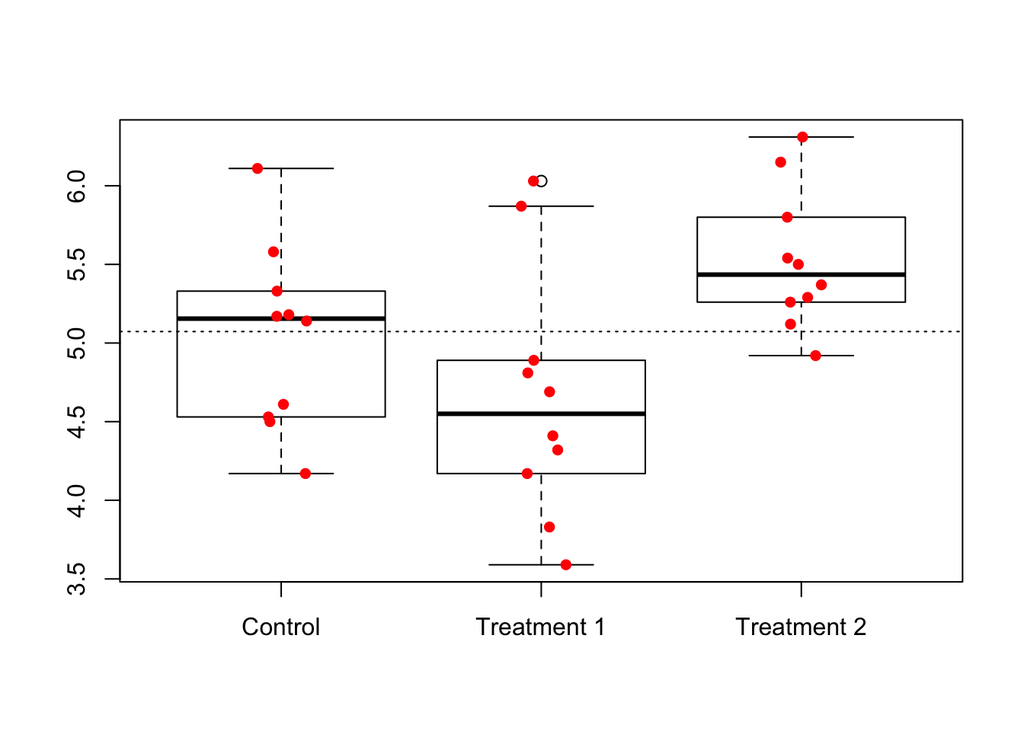

```r
boxplot(weight ~ group, data=df)
stripchart(weight ~ group, add=T, method='jitter', vertical=T, pch=16, col="red", data = df)
abline(h=mean(df$weight), lty='dotted')  # draw dotted line at the grand mean
```

We want to test the null hypothesis, which is that the groups were sampled from the same population. To do this, we specifically test the hypothesis that the group means are equal using ANOVA.

# 2 Standard statistics

## 2.1 Standard ANOVA

The standard R function for ANOVA is the linear model: lm().

```r
model <- lm(weight ~ group, data=df)
result <- anova(model)
result
```

```
## Analysis of Variance Table
##
## Response: weight
##           Df  Sum Sq Mean Sq F value  Pr(>F)
## group      2  3.7663  1.8832  4.8461 0.01591 *
## Residuals 27 10.4921  0.3886
## ---
## Signif. codes:  0 '***' 0.001 '**' 0.01 '*' 0.05 '.' 0.1 ' ' 1
```

Instead of accepting this p-value, which is based on assumptions about the distribution of the data, we can bootstrap the test. It is easy to grab the F-weight for each resample, as computed by lm():

```r
# get the F-statistic from lm()
F0 = result$`F value`[1]

# Bootstrap the F-statistic to compute the p-value
deals <- 10000
bootF <- rep(NA,deals)
for(i in 1:deals){
    df$boot <- sample(df$weight, replace=T)
    bootresult <- anova(lm(boot ~ group, data=df))
    bootF[i] <- bootresult$`F value`[1]
}
pval <- sum(bootF > F0)/deals
```

Let’s look at the resulting F-distribution:

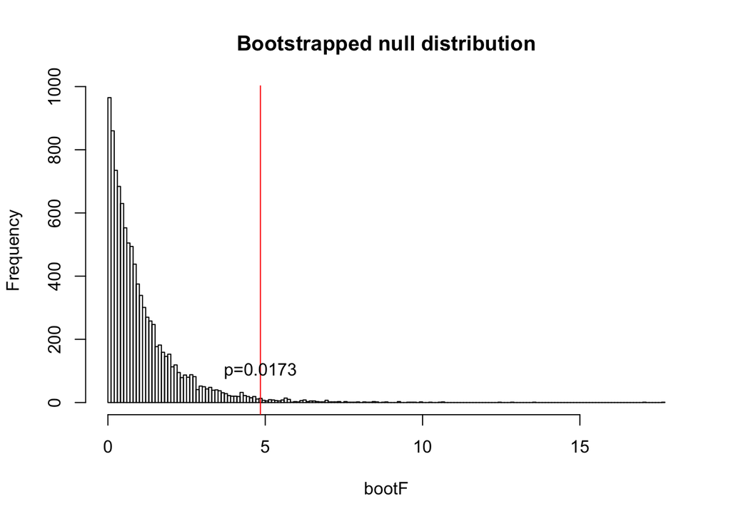

```r
hist(bootF, breaks='FD', main="Bootstrapped null distribution")
abline(v=F0, col='red')
text(x=F0, y=100, labels=paste("p=",pval,sep=""))
```

Looking at the QQ plot, we see the theoretical F-distribution.

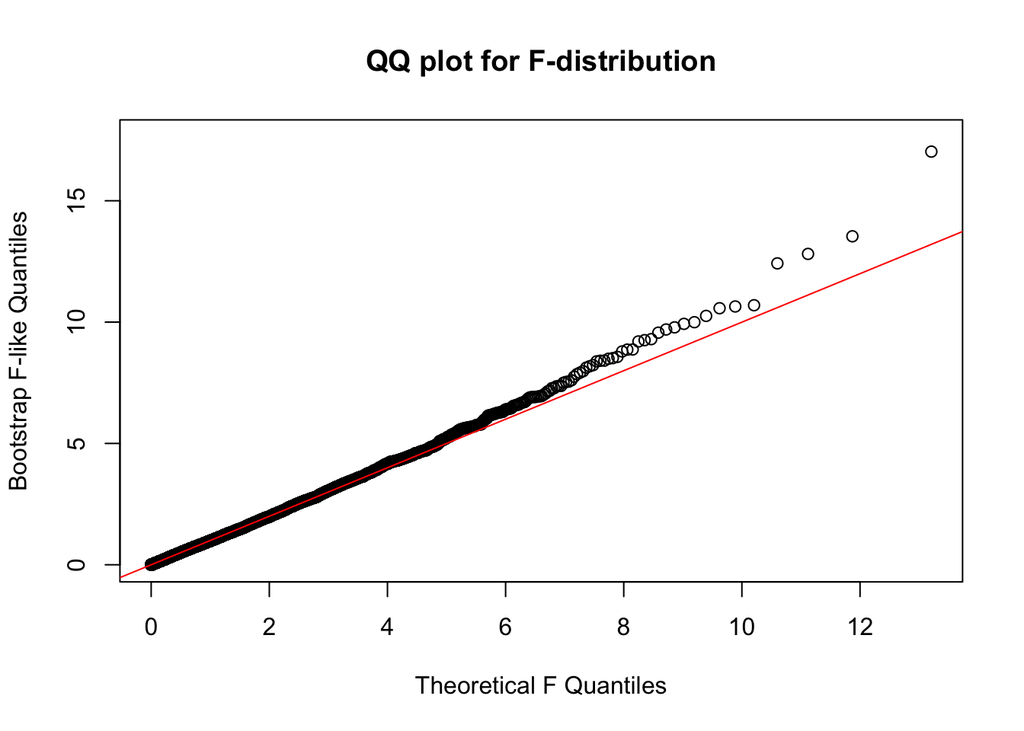

```r
dfB <- result$Df[1]
dfW <- result$Df[2]
qqplot( qf( seq(0,1,length=deals), dfB, dfW), bootF,
        main="QQ plot for F-distribution",
        xlab="Theoretical F Quantiles",
        ylab="Bootstrap F-like Quantiles")
abline(0, 1, col='red')
```

### 2.1.1 Post-hoc tests

We can easily do post-hoc t-tests using standard R functions.

```r
pairwise.t.test(df$weight, df$group, p.adjust="bonferroni")
```

```
##
##  Pairwise comparisons using t tests with pooled SD
##
## data:  df$weight and df$group
##
##             Control Treatment 1
## Treatment 1 0.583   -
## Treatment 2 0.263   0.013
##
## P value adjustment method: bonferroni
```

The result states that there are statistically significant differences between treatment 1 and treatment 2.

### 2.1.2 Evaluating assumptions

We could check the homogeneity of variance assumption using a test. If the data is normally distributed, the Bartlett test is the most powerful test to use. However, it is sensitive to data which is not non-normally distribution; it is more likely to return a “false positive” when the data is non-normal. There is also Levene’s test, which is more robust to departures from normality than Bartlett’s test. And finally, there is the Fligner-Killeen test, which is a non-parametric test that is very robust against departures from normality.

```r
bartlett.test(weight ~ group, data=df)
```

```
##
##  Bartlett test of homogeneity of variances
##
## data:  weight by group
## Bartlett's K-squared = 2.8786, df = 2, p-value = 0.2371
```

```r
fligner.test(weight ~ group, data=df)
```

```
##
##  Fligner-Killeen test of homogeneity of variances
##
## data:  weight by group
## Fligner-Killeen:med chi-squared = 2.3499, df = 2, p-value = 0.3088
```

```r
library(car)
leveneTest(weight ~ group, data=df)
```

```
## Levene's Test for Homogeneity of Variance (center = median)
##       Df F value Pr(>F)
## group  2  1.1192 0.3412
##       27
```

There’s also some plots to look at. The residual plot shows if there is a pattern in the residuals. It should indicate homoscedasticity. The next plot is a QQ plot that looks for normality of the residuals; if they are not normal, the assumptions of ANOVA are potentially violated. A third plot is a scale-location plot, which specifically looks at if the residuals increase with the fitted weights. Finally, the leverage plot gives an idea of which levels of the factor are best fitted.

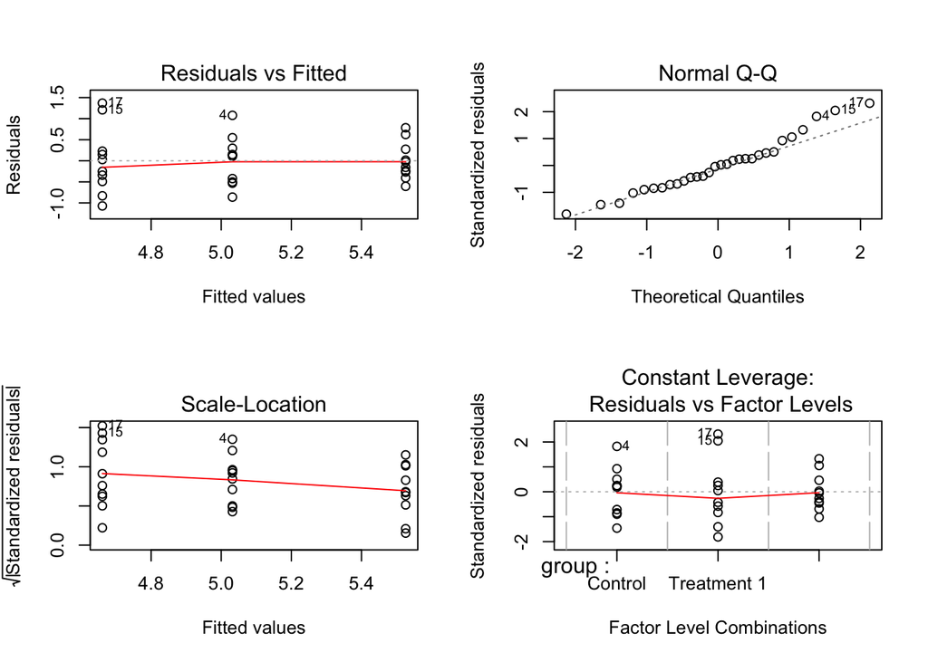

```r
par(mfrow=c(2,2))
plot(model)
```

## 2.2 Nonparametric tests

We can use the Kruskal-Wallis rank sum test.

```r
kruskal.test(weight~group, data=df)
```

```
##
##  Kruskal-Wallis rank sum test
##
## data:  weight by group
## Kruskal-Wallis chi-squared = 7.9882, df = 2, p-value = 0.01842
```

### 2.2.1 Post-hoc tests

For post-hoc testing, we can use pairwise Mann-Whitney U tests.

```r
pairwise.wilcox.test(df$weight, df$group, p.adjust.method="bonferroni", exact=F, correct=F)
```

```
##
##  Pairwise comparisons using Wilcoxon rank sum test
##
## data:  df$weight and df$group
##
##             Control Treatment 1
## Treatment 1 0.56    -
## Treatment 2 0.18    0.03
##
## P value adjustment method: bonferroni
```

# 3 Bootstrap statistics

Let’s construct a more general bootstrap ANOVA for ourselves. There are two common statistics to do this. The first is to simply look at the sum of squares of the means around the grand mean. The second is to turn this into a ratio statistic like the F-statistic. There are also two ways of doing the resampling, just like in the two-group comparsions: one-box and two-box.

## 3.1 One-box bootstrap

First, let’s define some preliminary functions to compute the sum of squares, sum of abs, and the test statistics:

```r
# Define functions to compute the Sum of Squares, and Sum of Abs
ssq <- function(x) sum(x^2)
sab <- function(x) sum(abs(x))

SSstat <- function(Y, group, center=mean, agg=ssq){
    groupMeans = ave( Y, group, FUN = center)
    SSB = agg(groupMeans - center(Y))
    return(SSB)
}

# A more general function to compute the F-statistic
Fstat <- function(Y, group, center=mean, agg=ssq) {
    groupMeans = ave( Y, group, FUN = center)
    SSB = agg(groupMeans - center(Y))
    SSW = agg(Y - groupMeans)
    return( SSB / SSW)
}
```

### 3.1.1 ANOVA using L2-norm

Now let’s implement the one-box bootstrap using the mean and sum of squares:

```r
# Run it on the dataframe to get the test statistic:
SS0 <- SSstat(df$weight,df$group, center=mean, agg=ssq)
F0 <- Fstat(df$weight,df$group, center=mean, agg=ssq)

# Bootstrap the SS-statistic to compute the p-value
bootSS <- rep(NA,deals)
for(i in 1:deals){
    df$boot <- sample(df$weight, replace=T)
    bootSS[i] <- SSstat(df$boot, df$group, center=mean, agg=ssq)
}
pval.SS <- sum(bootSS > SS0)/deals

# Bootstrap the F-statistic to compute the p-value
bootF <- rep(NA,deals)
for(i in 1:deals){
    df$boot <- sample(df$weight, replace=T)
    bootF[i] <- Fstat(df$boot, df$group, center=mean, agg=ssq)
}
pval.F <- sum(bootF > F0)/deals
```

Take a look at the null distribution for the SS statistic:

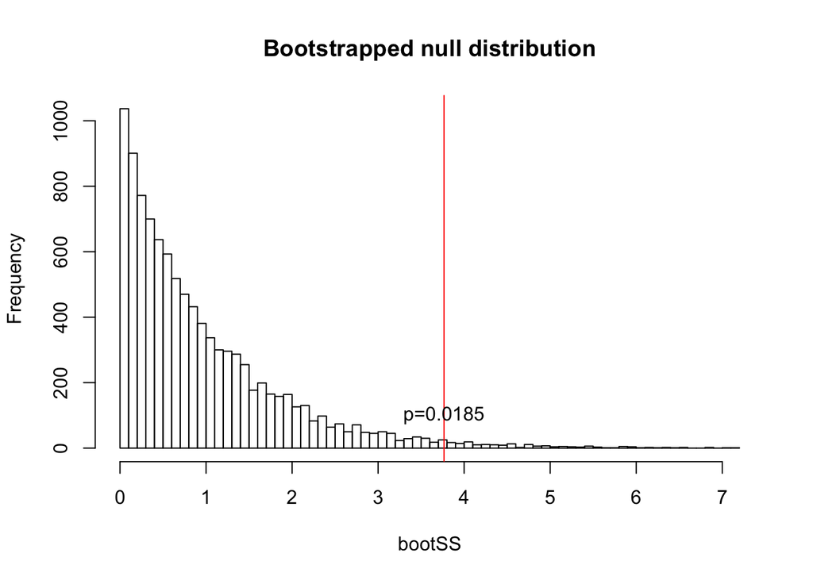

```r
hist(bootSS, breaks='FD', main="Bootstrapped null distribution")
abline(v=SS0, col='red')
text(x=SS0, y=100, labels=paste("p=",pval.SS,sep=""))
```

And take a look at the null distribution for the F statistic:

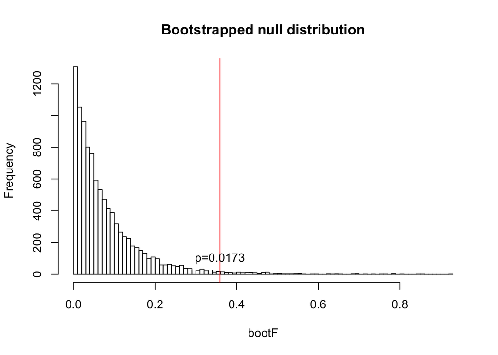

```r
hist(bootF, breaks='FD', main="Bootstrapped null distribution")
abline(v=F0, col='red')
text(x=F0, y=100, labels=paste("p=",pval,sep=""))
```

We can compare the bootstrapped null distribution, in which we ignored counting degrees of freedom, with the theoretical F-distribution with the appropriate degrees of freedom. Notice that the only difference is a scaling (which is indicated by the slope, which is not the identity but some other constant).

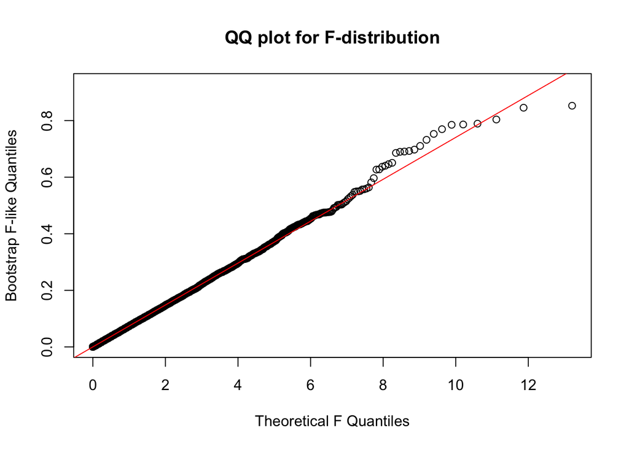

```r
qqplot( qf( seq(0,1,length=deals), dfB, dfW), bootF,
        main="QQ plot for F-distribution",
        xlab="Theoretical F Quantiles",
        ylab="Bootstrap F-like Quantiles")
abline(0, dfB/dfW, col='red')
```

### 3.1.2 ANOVA using L1-norm

Now let’s implement the one-box bootstrap using the mean and sum of absolute deviations:

```r
# Run it on the dataframe to get the test statistic:
SS0 <- SSstat(df$weight,df$group, center=mean, agg=sab)
F0 <- Fstat(df$weight,df$group, center=mean, agg=sab)

# Bootstrap the S-abs statistic to compute the p-value
bootSS <- rep(NA,deals)
for(i in 1:deals){
    df$boot <- sample(df$weight, replace=T)
    bootSS[i] <- SSstat(df$boot, df$group, center=mean, agg=sab)
}
pval.SS <- sum(bootSS > SS0)/deals

# Bootstrap the F-abs statistic to compute the p-value
bootF <- rep(NA,deals)
for(i in 1:deals){
    df$boot <- sample(df$weight, replace=T)
    bootF[i] <- Fstat(df$boot, df$group, center=mean, agg=sab)
}
pval.F <- sum(bootF > F0)/deals
```

Take a look at the null distribution for the S-abs statistic:

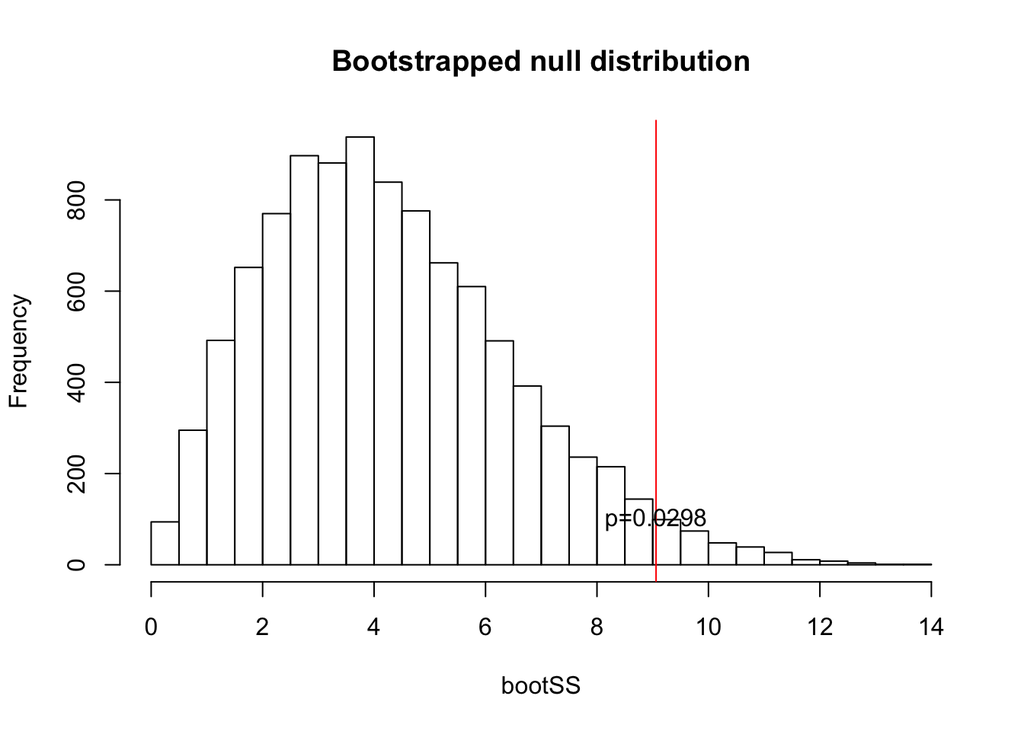

```r
hist(bootSS, breaks='FD', main="Bootstrapped null distribution")
abline(v=SS0, col='red')
text(x=SS0, y=100, labels=paste("p=",pval.SS,sep=""))
```

Now take a look at the null distribution for the F statistic. We get a very similar p-value:

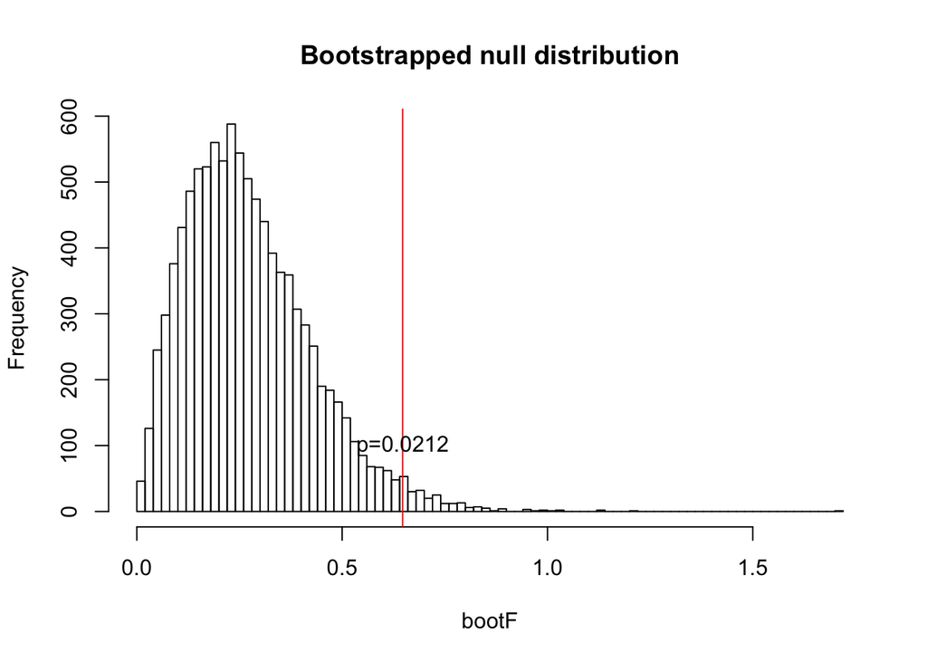

```r
hist(bootF, breaks='FD', main="Bootstrapped null distribution")
abline(v=F0, col='red')
text(x=F0, y=100, labels=paste("p=",pval.F,sep=""))
```

This distribution looks like a chi-squared distribution.

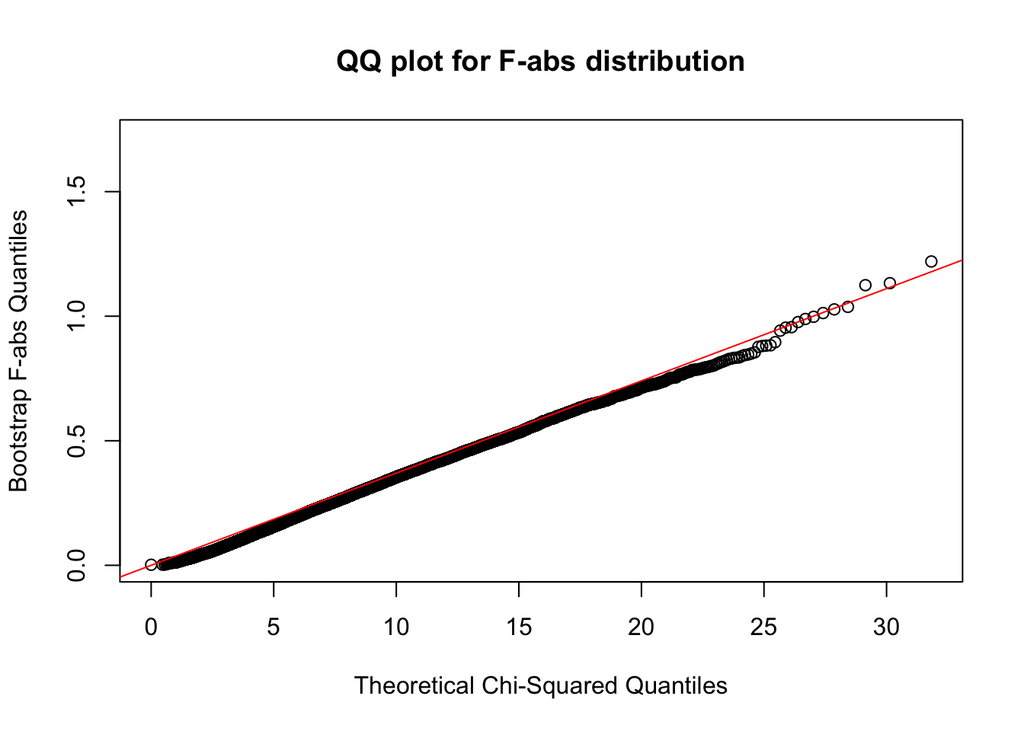

```r
qqplot( qchisq( seq(0,1,length=deals), 8), bootF,
        main="QQ plot for F-abs distribution",
        xlab="Theoretical Chi-Squared Quantiles",
        ylab="Bootstrap F-abs Quantiles")
abline(0,1/dfW, col='red')
```

### 3.1.3 Rank test

Now let’s implement the one-box bootstrap using ranks:

```r
# Run it on the dataframe to get the test statistic:
F0 = Fstat(rank(df$weight),df$group, center=mean, agg=ssq)

# Bootstrap the F-statistic to compute the p-value
bootF <- rep(NA,deals)
for(i in 1:deals){
    df$boot <- sample(df$weight, replace=T)
    bootF[i] <- Fstat(rank(df$boot), df$group, center=mean, agg=ssq)
}
pval <- sum(bootF > F0)/deals
```

Take a look at the null distribution for the F statistic. We get a very similar p-value:

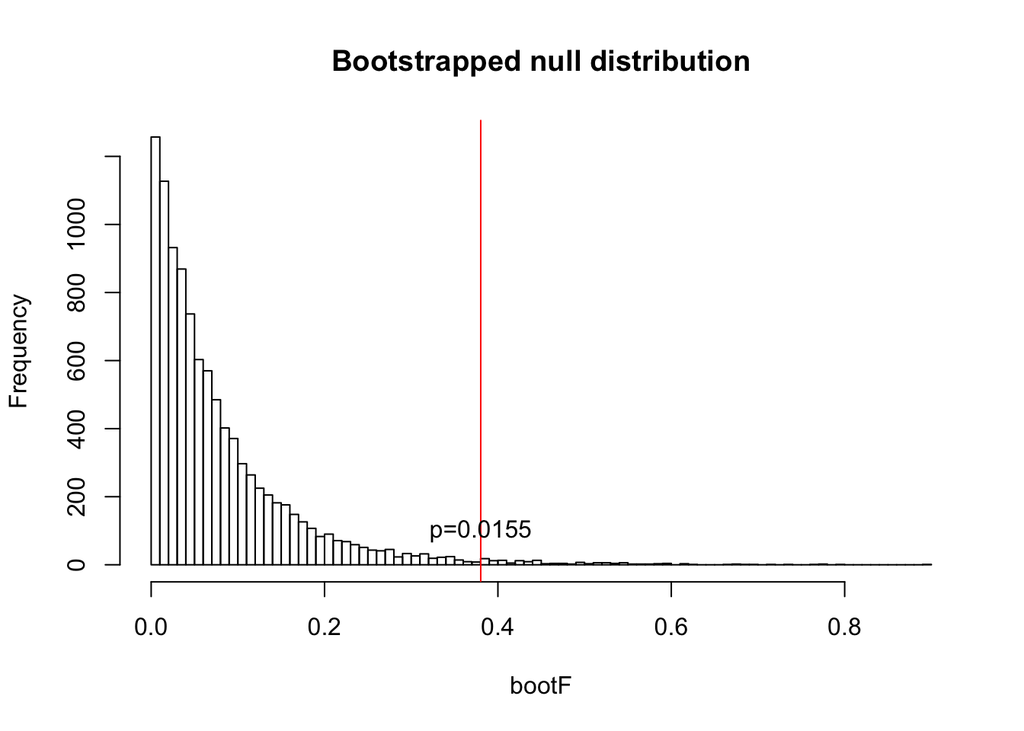

```r
hist(bootF, breaks='FD', main="Bootstrapped null distribution")
abline(v=F0, col='red')
text(x=F0, y=100, labels=paste("p=",pval,sep=""))
```

We can compare the bootstrapped null distribution with the theoretical F-distribution with the appropriate degrees of freedom. Notice that the only difference is a scaling (which is indicated by the slope, which is not the identity but some other constant).

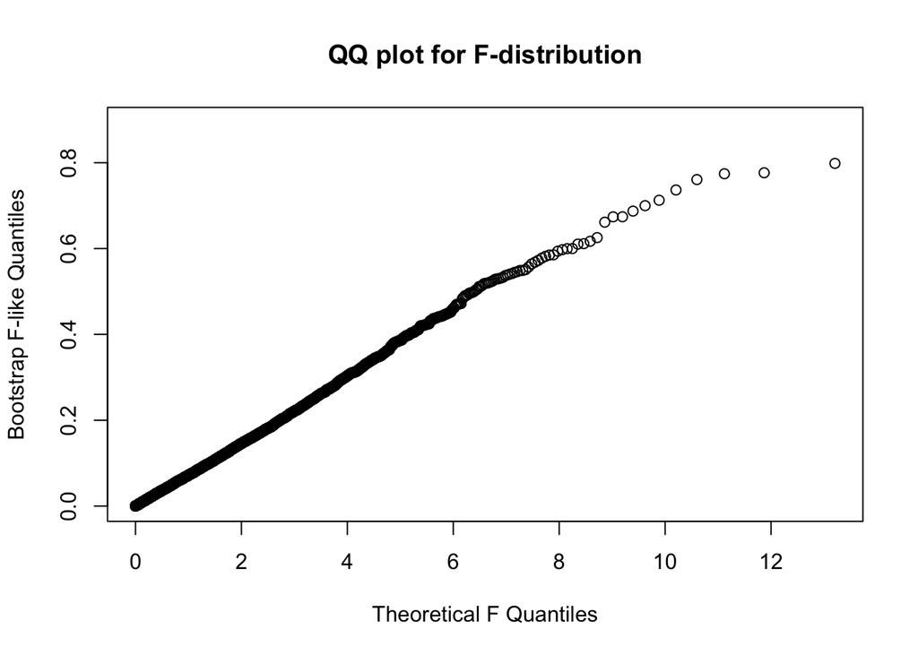

```r
qqplot( qf( seq(0,1,length=deals), dfB, dfW), bootF,
        main="QQ plot for F-distribution",
        xlab="Theoretical F Quantiles",
        ylab="Bootstrap F-like Quantiles")
```

## 3.2 Many-box bootstrap

### 3.2.1 ANOVA using L2-norm

Now let’s implement the many-box bootstrap using the mean and sum of squares:

```r
# Run it on the dataframe to get the test statistic:
SS0 <- SSstat(df$weight,df$group, center=mean, agg=ssq)
F0 <- Fstat(df$weight,df$group, center=mean, agg=ssq)

# Bootstrap the SS-statistic to compute the p-value
bootSS <- rep(NA,deals)
residuals <- df$weight - ave(df$weight, df$group)
for(i in 1:deals){
    df$boot <- ave(residuals, df$group, FUN=function(x) sample(x, replace=TRUE))
    bootSS[i] <- SSstat(df$boot, df$group, center=mean, agg=ssq)
}
pval.SS <- sum(bootSS > SS0)/deals

# Bootstrap the F-statistic to compute the p-value
bootF <- rep(NA,deals)
residuals <- df$weight - ave(df$weight, df$group)
for(i in 1:deals){
    df$boot <- ave(residuals, df$group, FUN=function(x) sample(x, replace=TRUE))
    bootF[i] <- Fstat(df$boot, df$group, center=mean, agg=ssq)
}
pval.F <- sum(bootF > F0)/deals
```

Take a look at the null distribution for the SS statistic:

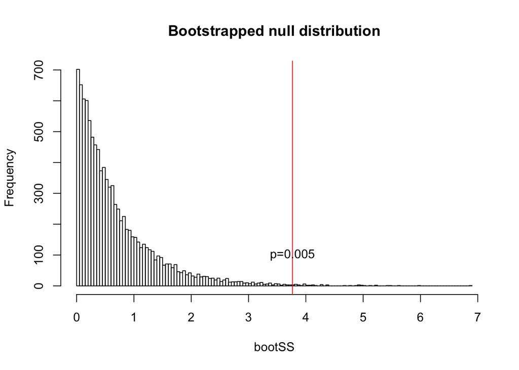

```r
hist(bootSS, breaks='FD', main="Bootstrapped null distribution")
abline(v=SS0, col='red')
text(x=SS0, y=100, labels=paste("p=",pval.SS,sep=""))
```

And take a look at the null distribution for the F statistic:

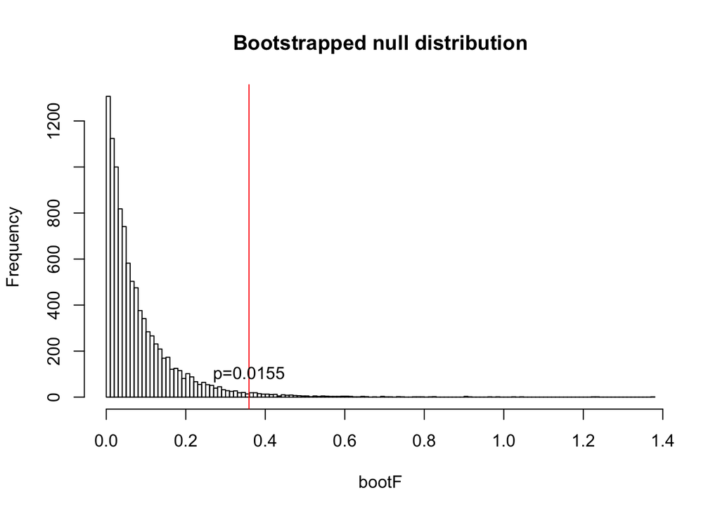

```r
hist(bootF, breaks='FD', main="Bootstrapped null distribution")
abline(v=F0, col='red')
text(x=F0, y=100, labels=paste("p=",pval,sep=""))
```

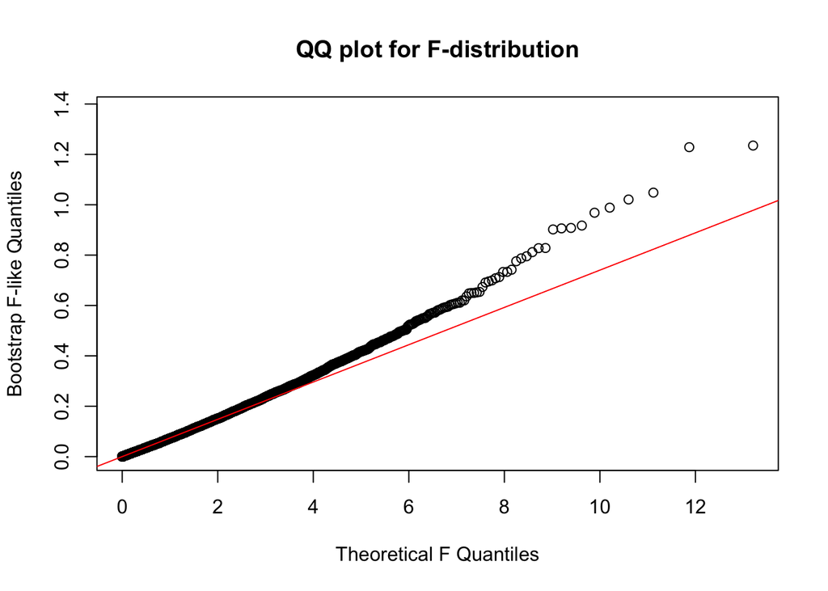

```r
qqplot( qf( seq(0,1,length=deals), dfB, dfW), bootF,
        main="QQ plot for F-distribution",
        xlab="Theoretical F Quantiles",
        ylab="Bootstrap F-like Quantiles")
abline(0, dfB/dfW, col='red')
```

### 3.2.2 ANOVA using L1-norm

```r
# Run it on the dataframe to get the test statistic:
SS0 <- SSstat(df$weight,df$group, center=mean, agg=sab)
F0 <- Fstat(df$weight,df$group, center=mean, agg=sab)

# Bootstrap the S-abs statistic to compute the p-value
bootSS <- rep(NA,deals)
for(i in 1:deals){
    df$boot <- ave(residuals, df$group, FUN=function(x) sample(x, replace=TRUE))
    bootSS[i] <- SSstat(df$boot, df$group, center=mean, agg=sab)
}
pval.SS <- sum(bootSS > SS0)/deals

# Bootstrap the F-abs statistic to compute the p-value
bootF <- rep(NA,deals)
for(i in 1:deals){
    df$boot <- ave(residuals, df$group, FUN=function(x) sample(x, replace=TRUE))
    bootF[i] <- Fstat(df$boot, df$group, center=mean, agg=sab)
}
pval.F <- sum(bootF > F0)/deals
```

Take a look at the null distribution for the S-abs statistic:

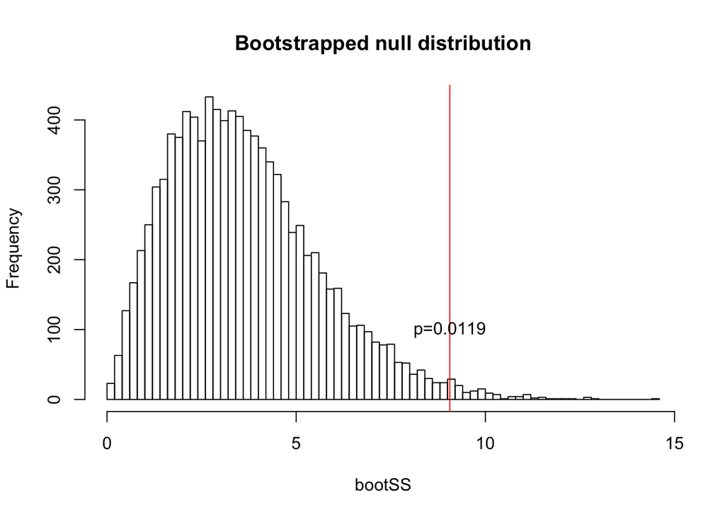

```r
hist(bootSS, breaks='FD', main="Bootstrapped null distribution")
abline(v=SS0, col='red')
text(x=SS0, y=100, labels=paste("p=",pval.SS,sep=""))
```

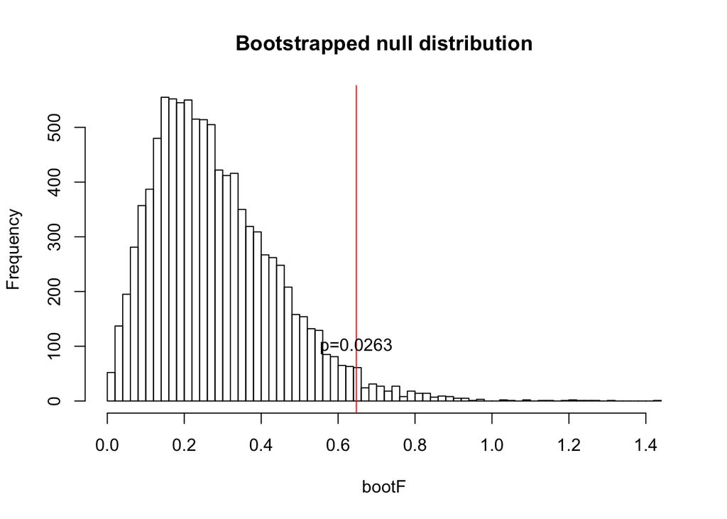

```r
hist(bootF, breaks='FD', main="Bootstrapped null distribution")
abline(v=F0, col='red')
text(x=F0, y=100, labels=paste("p=",pval.F,sep=""))
```

This distribution looks like a chi-squared distribution.

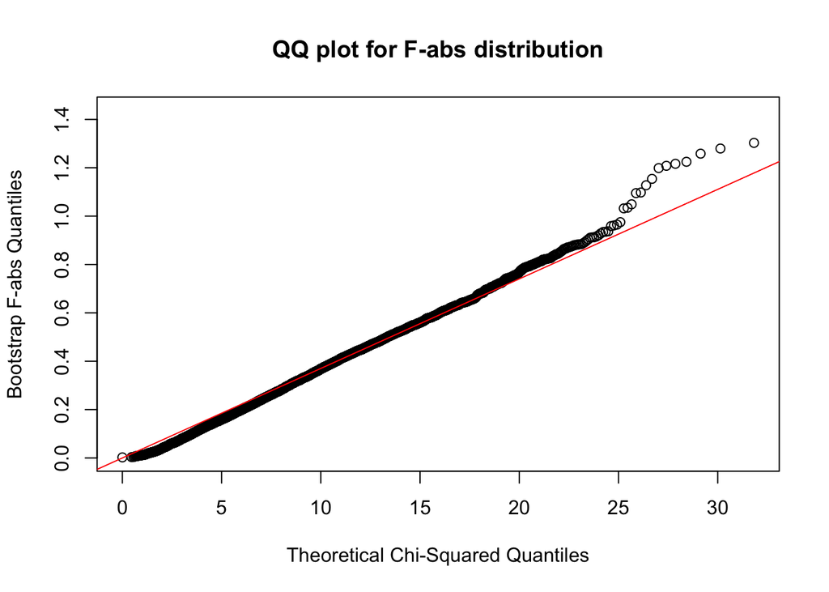

```r
qqplot( qchisq( seq(0,1,length=deals), 8), bootF,
        main="QQ plot for F-abs distribution",
        xlab="Theoretical Chi-Squared Quantiles",
        ylab="Bootstrap F-abs Quantiles")
abline(0,1/dfW, col='red')
```

# 4 Optimization for R

In the tutorial on Comparing the Means of Two Populations, we learned that for-loops were inefficient, and we could significantly speed up the bootstrap algorithms by vectorizing the code. Here are the vectorized functions.

```r
# faster mean and standard deviation
mean.fast <- function(x) sum(x) / length(x)
sd.fast <- function(x){
    mu <- mean.fast(x)
    sqrt(sum((x - mu)^2) / (length(x)-1))
}

# Define functions to compute the Sum of Squares, and Sum of Abs
ssq <- function(x) sum(x^2)
sab <- function(x) sum(abs(x))

# A more general function to compute the F-statistic
Fstat <- function(Y, group, center=mean.fast, agg=ssq) {
    groupMeans = ave( Y, group, FUN = center)
    SSB = agg(groupMeans - center(Y))
    SSW = agg(Y - groupMeans)
    return( SSB / SSW)
}
```

```r
Y <- df$weight
G <- df$group
center <- mean.fast
nboot <- 10000
```

Each of the bootstrap methods can be done using the following methods

```r
# one-box
y <- matrix(sample(Y, size = nboot * length(Y), replace = TRUE), nboot, length(Y) )
Fboot <- apply(y, 1, Fstat, group=G)
F0 <- Fstat(Y, G)
p1 <- sum(Fboot >= F0) / nboot

# one-box residuals
y <- matrix(sample( Y-ave( Y, G, FUN=center), size = nboot * length(Y), replace = TRUE), nboot, length(Y) )  # residuals
Fboot <- apply(y, 1, Fstat, group=G)
F0 <- Fstat(Y, G)
p1r <- sum(Fboot >= F0) / nboot

# one-box ranks
y <- matrix(sample( Y, size = nboot * length(Y), replace = TRUE), nboot, length(Y) )  # residuals
y.rank <- t(apply(y, 1, rank))
Fboot <- apply(y.rank, 1, Fstat, group=G)
F0 <- Fstat(rank(Y), G)
p.rank <- sum(Fboot >= F0) / nboot

# many-box residuals
residuals <- Y-ave( Y, G, FUN=center)
y <- replicate(nboot, ave(residuals, G, FUN=function(x) sample(x, replace=TRUE)), simplify="array")
Fboot <- apply(y, 2, Fstat, group=G)
F0 <- Fstat(Y, G)
p2r <- sum(Fboot >= F0) / nboot
```

Let’s compare all our resulting p-values

|  | p-value |
| --- | --- |
| Standard ANOVA | 0.0159 |
| one-box L2 | 0.0185 |
| one-box residuals L2 | 0.0162 |
| one-box L1 | 0.0202 |
| one-box residuals L1 | 0.0203 |
| one-box, median L1 | 0.0767 |
| one-box residuals, median L1 | 0.0490 |
| many-box residuals L2 | 0.0230 |
| many-box residuals L1 | 0.0305 |
| many-box residuals, median L1 | 0.0875 |
| Kruskal-Wallis | 0.0184 |
| rank | 0.0149 |